# Customer_Churn_test

## Used libraries

```r
library(tidyverse)
library(sqldf)
library(ggplot2)
library(corrplot)
library(car)
library(doParallel)
library(corrplot)
library(lmtest) # BPtest
library(caret)
library(dplyr)
library(pROC)
library(ROCR)
library(latticeExtra)
```

```r
# Install all the packages at once. Uncomment and run if needed
# packages <- c('tidyverse', 'sqldf', 'rgeos', 'ggplot2', 'corrplot', 'caret', 'car', 'doParallel','doParallel','lmtest', 'dplyr', 'corrplot','pROC', 'ROCR', 'latticeExtra )
# ipak(packages)
```

## Introduction

The data includes basic information of customers of a telecommunication company along with services they have signed up for. It comes in four chunks. Two of them are related to basic information and the other two show the usage of the services they signed up for. The aim of this analysis is to fit a model to predict the churn rate of the customers using the basic information and the usage of services. In this analysis we are going to fit logistic regression using Glm function. Since the regression models provide very high interpretability by providing coefficients and standard errors, as well as test statistics, I decided to proceed with the regression model. Additionally, I will show my approach on checking model assumptions, other than the predictability of the model. Checking model assumptions, such as linearity, independence, normality (errors are normally distributed) and constant variance helps us to have more accurate coefficients in case we are interested in using interpretability of the model. Also, it allows us to check how much we can rely on the result of the model and to compare predictability or interpretability of several models.

## Data Preparation

I start with merging data set into one file:

Reading in customer Demographic Data:

```r
demog1 <- read_csv("demography01.csv")
demog2 <- read_csv("demography02.csv")
```

Reading in customer usage data for the services they have applied

```r
usage1 <- read_csv("usage01.csv")
usage2 <- read_csv("usage02.csv")
```

Binding the two parts for demographic and usage data

```r
demog <- rbind(demog1,demog2)
usage <- rbind(usage1,usage2)
```

# Join two parts

In this part, I used SQL script to join the customers demographic and usage data. Depending on the size of the data set, there are different ways that might be faster or slower.

```r
customer <- sqldf("SELECT *
                FROM demog
                JOIN usage USING(Customer)")
```

The column I intended to use for the prediction is “Churn within last month.” However, for easier usage I renamed it to Churn

```r
colnames(customer)[37] <- "churn"
```

Saving the whole data in CSV for further reference and cross checking.

```r
write.csv(customer, "customer_all.csv")
```

# Summary of data

Checking to develop a general idea of different variables (covariates or predictors).

```r
str(customer)
```

```
## 'data.frame':    1000 obs. of  37 variables:
##  $ Customer                     : chr  "ID0001" "ID0002" "ID0003" "ID0004" ...
##  $ Geographic indicator         : chr  "Zone 2" "Zone 3" "Zone 3" "Zone 2" ...
##  $ Months with service          : num  13 11 68 33 23 41 45 38 45 68 ...
##  $ Age in years                 : num  44 33 52 33 30 39 22 35 59 41 ...
##  $ Marital status               : chr  "Married" "Married" "Married" "Unmarried" ...
##  $ Years at current address     : num  9 7 24 12 9 17 2 5 7 21 ...
##  $ Household income in thousands: num  64 136 116 33 30 78 19 76 166 72 ...
##  $ Level of education           : chr  "Graduate" "Doctorate" "Did Not Complete High School" "Completed High School" ...
##  $ Years with current employer  : num  5 5 29 0 2 16 4 10 31 22 ...
##  $ Retired                      : chr  "No" "No" "No" "No" ...
##  $ Gender                       : chr  "Male" "Male" "Female" "Female" ...
##  $ Number of people in household: num  2 6 2 1 4 1 5 3 5 3 ...
##  $ Customer category            : chr  "Category 1" "Category 4" "Category 3" "Category 1" ...
##  $ Toll free service            : chr  "No" "Yes" "Yes" "No" ...
```

[output cut: 23 more lines]

```r
summary(customer)
```

```
##    Customer         Geographic indicator Months with service
##  Length:1000        Length:1000          Min.   : 1.00
##  Class :character   Class :character     1st Qu.:17.00
##  Mode  :character   Mode  :character     Median :34.00
##                                          Mean   :35.53
##                                          3rd Qu.:54.00
##                                          Max.   :72.00
##   Age in years   Marital status     Years at current address
##  Min.   :18.00   Length:1000        Min.   : 0.00
##  1st Qu.:32.00   Class :character   1st Qu.: 3.00
##  Median :40.00   Mode  :character   Median : 9.00
##  Mean   :41.68                      Mean   :11.55
##  3rd Qu.:51.00                      3rd Qu.:18.00
##  Max.   :77.00                      Max.   :55.00
##  Household income in thousands Level of education
##  Min.   :   9.00               Length:1000
##  1st Qu.:  29.00               Class :character
##  Median :  47.00               Mode  :character
##  Mean   :  77.53
##  3rd Qu.:  83.00
##  Max.   :1668.00
##  Years with current employer   Retired             Gender
##  Min.   : 0.00               Length:1000        Length:1000
##  1st Qu.: 3.00               Class :character   Class :character
##  Median : 8.00               Mode  :character   Mode  :character
##  Mean   :10.99
##  3rd Qu.:17.00
##  Max.   :47.00
##  Number of people in household Customer category  Toll free service
##  Min.   :1.000                 Length:1000        Length:1000
##  1st Qu.:1.000                 Class :character   Class :character
##  Median :2.000                 Mode  :character   Mode  :character
##  Mean   :2.331
##  3rd Qu.:3.000
##  Max.   :8.000
##  Equipment rental   Calling card service Wireless service
##  Length:1000        Length:1000          Length:1000
##  Class :character   Class :character     Class :character
##  Mode  :character   Mode  :character     Mode  :character
##
```

[output cut: 36 more lines]

```
##
##  Call waiting       Call forwarding    Three way calling
##  Length:1000        Length:1000        Length:1000
##  Class :character   Class :character   Class :character
##  Mode  :character   Mode  :character   Mode  :character
##
##
##
##  Electronic billing    churn
##  Length:1000        Length:1000
##  Class :character   Class :character
##  Mode  :character   Mode  :character
##
##
##
```

Based on the summary there is no missing values (NAs) in our data. Further checking for NAs in case of missing anything using human eyes.

```r
any(is.na(customer))
```

```
## [1] FALSE
```

# Exploratory data analysis

In this section I checked the distribution of the continuous variables, as well as categorical variables. This is to deteremine if they are following normal distribution, in case we would like to rely on confidence interval in the future for model assumptions. Also, it helps to have a general overview of our data to help us further on in the analysis.

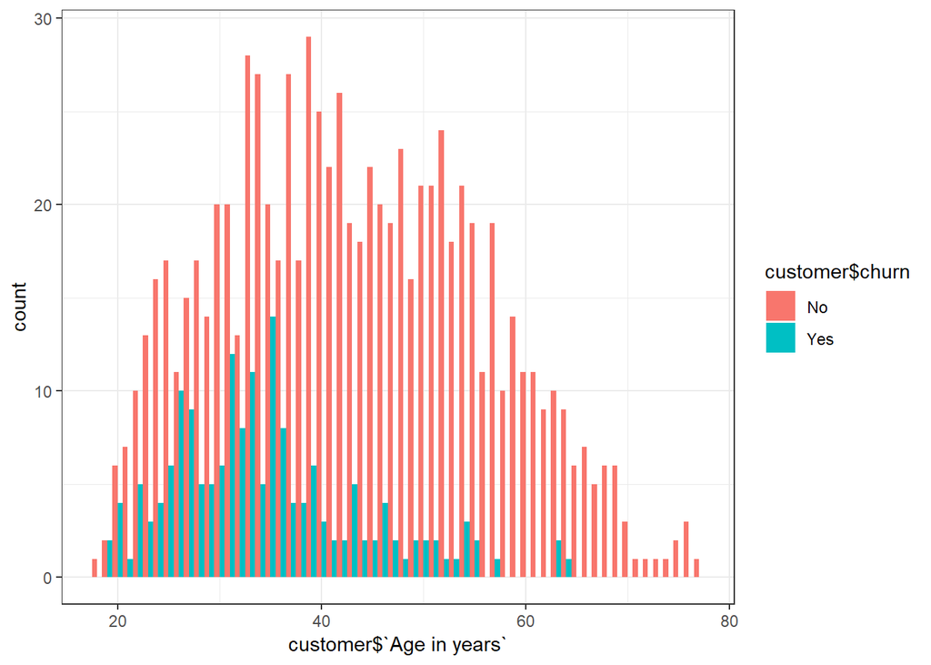

```r
ggplot(customer,aes(x=customer$`Age in years`,group=customer$churn,fill=customer$churn))+
  geom_histogram(position="dodge",binwidth=1)+theme_bw()
```

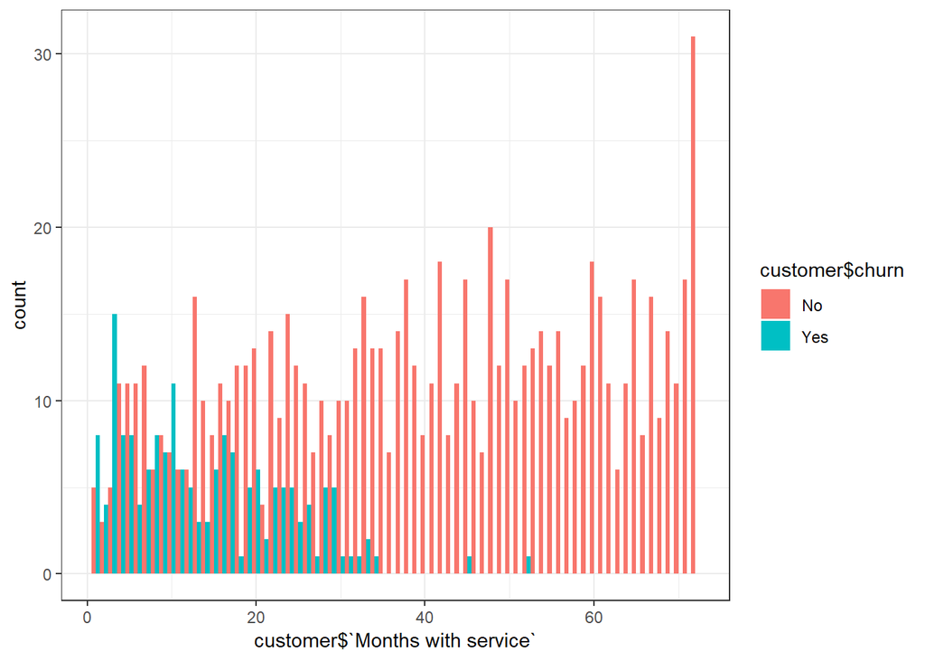

```r
ggplot(customer,aes(x=customer$`Months with service`,group=customer$churn,fill=customer$churn))+
  geom_histogram(position="dodge",binwidth=1)+theme_bw()
```

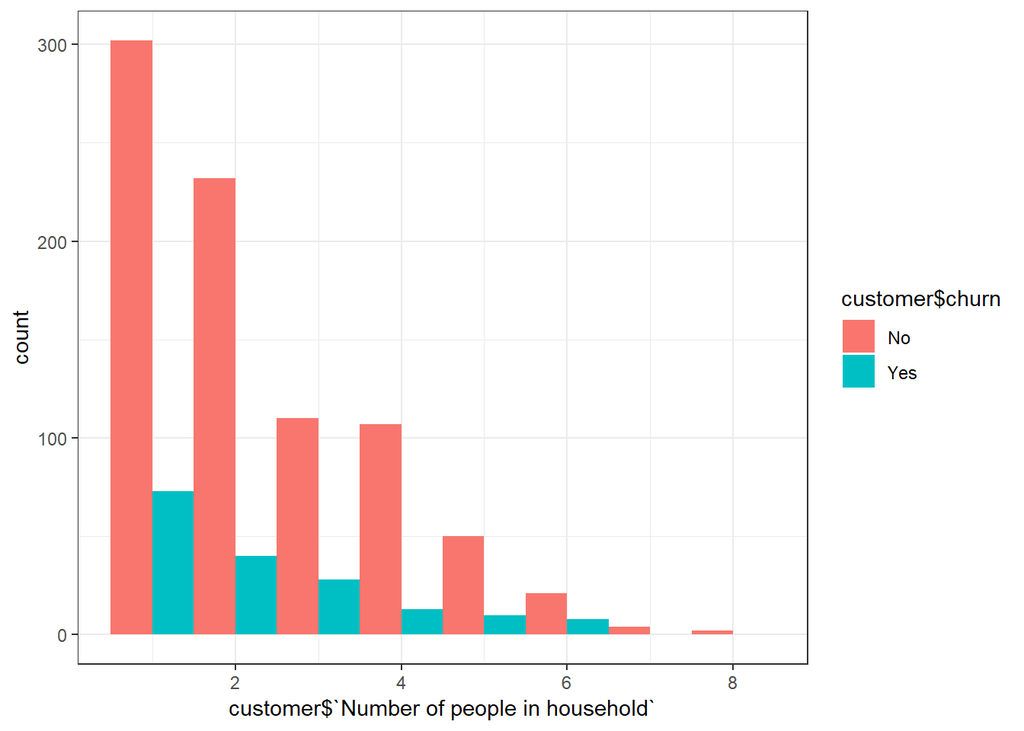

```r
ggplot(customer,aes(x=customer$`Number of people in household`,group=customer$churn,fill=customer$churn))+
  geom_histogram(position="dodge",binwidth=1)+theme_bw()
```

The number of people in the household definitely does not follow normal distribution and we can clearly see Benford’s law in this distribution. Additionally, it shows both churned and not churned are having a positive skew (irrelevant of whether they are churned or not). This shows, particularly this variable, might not be our interest. However, I would wait and verify that in the next stages.

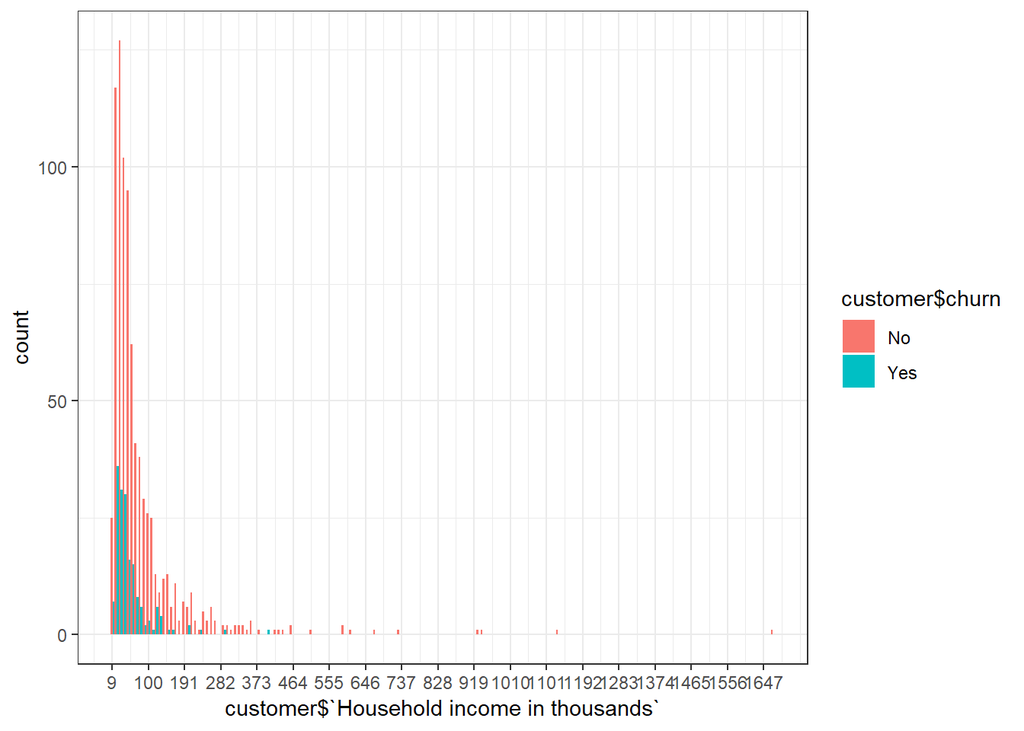

```r
ggplot(customer,aes(x=customer$`Household income in thousands`,group=customer$churn,fill=customer$churn))+
  geom_histogram(position="dodge",binwidth=10)+theme_bw()+
  scale_x_continuous(breaks = round(seq(min(customer$`Household income in thousands`), max(customer$`Household income in thousands`), by = 91),1))
```

Looking at household income (rescaled the x-axis for better readability), no matter whether churned or not, customers are having more counts around 38 thousands, forming heavily positive skewed distribution for both categories. However, the wide range of this distribution is noticeable.

## Checking Normality using QQnorm plot

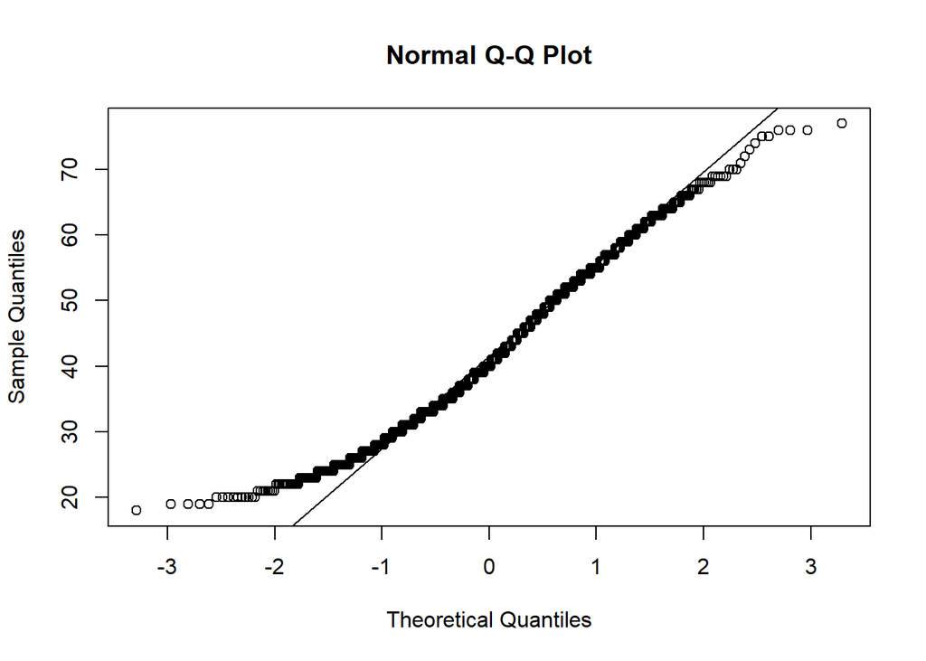

```r
qqnorm(customer$`Age in years`);qqline(customer$`Age in years`)
```

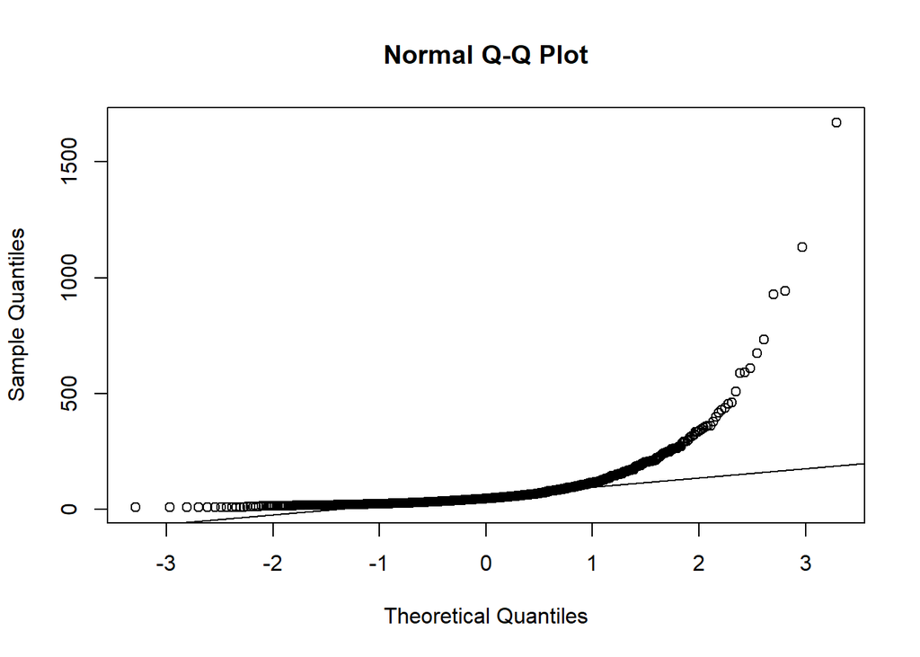

```r
qqnorm(customer$`Household income in thousands`);qqline(customer$`Household income in thousands`)
```

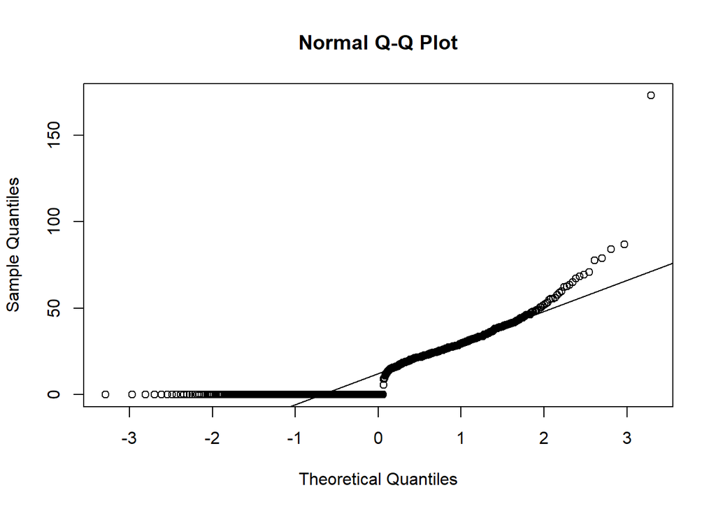

```r
qqnorm(customer$`Toll free last month`);qqline(customer$`Toll free last month`)
```

Checking normality of variables can be helpful at this stage as they might help us with model assumptions. However, normality will be checked for the best model on the residuals in the models assessment stage. Here, as an instance we can see normality does not apply for the three chosen variables (`Age in years`,`Household income in thousands` and `Toll free last month`).

Looking at the first plot of `age in years` variable, we might assume normality (However, such situations can be fixed by bootstraping or collecting more data). In order to verify the graphical evidence, we can use the Shapiro test to check normality further.

```r
shapiro.test(customer$`Age in years`)
```

```
##
##  Shapiro-Wilk normality test
##
## data:  customer$`Age in years`
## W = 0.97694, p-value = 1.678e-11
```

```r
shapiro.test(customer$`Age in years`[customer$churn=="No"])
```

```
##
##  Shapiro-Wilk normality test
##
## data:  customer$`Age in years`[customer$churn == "No"]
## W = 0.98367, p-value = 5.524e-08
```

Looking at the result of the Shapiro test with H Null, assuming normality for the customers who did not churn and all the customer’s age, we can see the extremely small p-value shows the significance of test statistics. We can reject the Null Hypothesis and verify none-normality in this particular distribution.

## Correlation

At this stage, I check for correlations between variables as well as correlation in the model residuals (next stages), as correlation can affect the model coefficient if interested in interpreting coefficients and standard errors. However, this might not affect the prediction. Looking at the number of variables, I noticed some of the variables seems to be related to each other and explain the same variability. For instance, I noticed `toll free service`, which is zero and one, is describing the same variability as `toll free last months` variable. Whenever it is one, the `toll free last month` variable has values and, whenever not, it is zero. The same goes to `equipment rental` and `equipment last month` (`equipment over tenure` which is removed already after assessing correlation). Therefore, I decide to get rid of `equipment rental`. Same goes with `calling card service` vs `calling card over tenure` or `calling card over last month` as well as `wireless service` and `wireless over tenure` and `wireless last month`.

With the help of the below plot and manual observation, I removed the related variables:

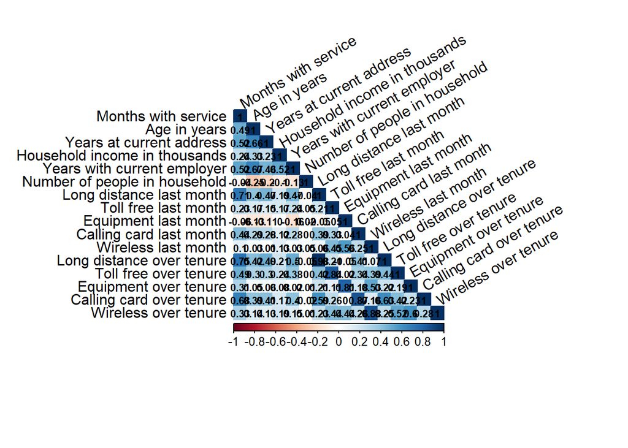

```r
customer %>%
  dplyr::select (`Months with service`,`Age in years`,`Years at current address`,  `Household income in thousands`,
                 `Years with current employer`,`Number of people in household`, `Long distance last month`,
                  `Toll free last month`, `Equipment last month`, `Calling card last month`,
                 `Wireless last month`, `Long distance over tenure`, `Toll free over tenure`,
                 `Equipment over tenure`, `Calling card over tenure`, `Wireless over tenure`) -> cor1
corrplot(cor(cor1), method = "color",tl.col = "black", number.cex = 0.7, type = "lower",
         addCoef.col = "black",tl.srt = 30)
```

As shown in the plot, it is clear that all of the variables ending with `over tenure` have very strong collinearity with their pairs, variables ending with `last months`. Therefore, I decided to remove the ones with ending `over tenure` as some of those had collinearity with other variables.

Since I suspected we might have problems when fitting the Glm model using the number of variables, I decided to remove collinearities further in order to help the algorithm to converge. Also months with service has collinearity with multiple variables that helps us to decide to remove it as well as `Years at current address`, `Years with current employer` and `Wireless last month`. Finally, the remaining highest collinearity is 0.39 which can be seen in the below illustration.

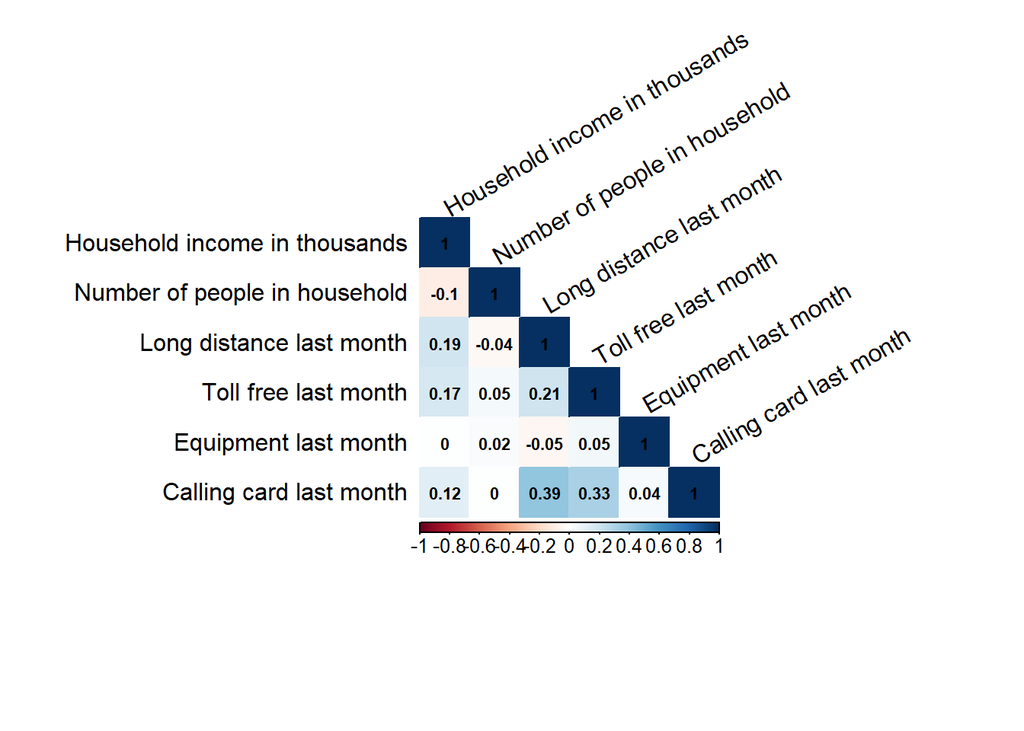

```r
customer %>%
  dplyr::select (`Household income in thousands`,`Number of people in household`, `Long distance last month`,
                 `Toll free last month`, `Equipment last month`, `Calling card last month`) -> cor2
                corrplot(cor(cor2), method = "color",tl.col = "black", number.cex = 0.7, type = "lower",addCoef.col = "black",tl.srt = 30)
```

## Checking imbalanced data set

```r
tb1 <- table(customer$churn)
# Producing Percentage
cbind(tb1,prop.table(tb1))
```

```
##     tb1
## No  828 0.828
## Yes 172 0.172
```

Per the above calculation, the churn rate is 17.2%. Since the proportion is far from equal, I can account for this issue using the partition function when creating train and holdout (test) set.

## Categorical Variables

Defining colours for plots:

```r
gucci.colours <- c("#A82B11", "goldenrod", "#0A6A56")
```

### Assessing categorical variables with Yes or No options (binomial)

```r
customer %>% dplyr::select(`Number of people in household`,  `Geographic indicator`, `Marital status`, `Level of education`,Retired:Gender, `Customer category`:`Wireless service`,
`Multiple lines`:`Electronic billing` , churn) -> categorical
categorical %>% dplyr::select(Retired, `Toll free service`:`Wireless service`, `Multiple lines`:`Electronic billing`, churn) -> cat2
gather(cat2, columns, value, -churn) -> cat3
```

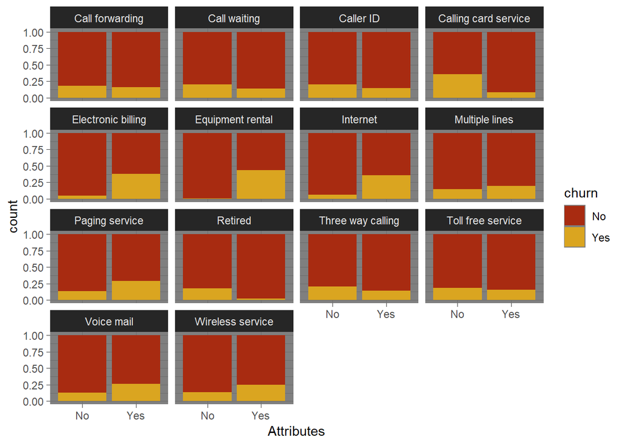

```r
ggplot(cat3)+
  geom_bar(aes(x = value, fill = churn), position = "fill", stat = "count")+
  facet_wrap(~columns)+
  xlab("Attributes") +
  scale_fill_manual(values=gucci.colours) +
  theme_dark()
```

There are major differences in churn or not churn between customers who have `calling card service`, `electric billing`, `equipment rental` (very significant), `internet`, `retired` and `voice mail`. While the churn rates does not seem to be drastically different in other categories.

Looking at the proportion of internet and electric billing we can see that those who do not have internet might not use electric billing which is a common sense. So these two variables can have a very high correlation. However by knowing more about variables description, it would be easier to find such collinearities. At this stage, I do not have enough information to quickly assess it. However, I believe one can have internet and not enable electric billing! So, I leave this when checking for correlation in the model.

Additionally, by knowing more details of the variables, we probably can categorize some of the continuous variables to acquire better predictability which can be tested separately.

### Categorical variables with multiple options

```r
categorical %>% dplyr::select(`Number of people in household`, `Geographic indicator`, `Marital status`, `Level of education`, Gender, `Customer category`) -> cat4
```

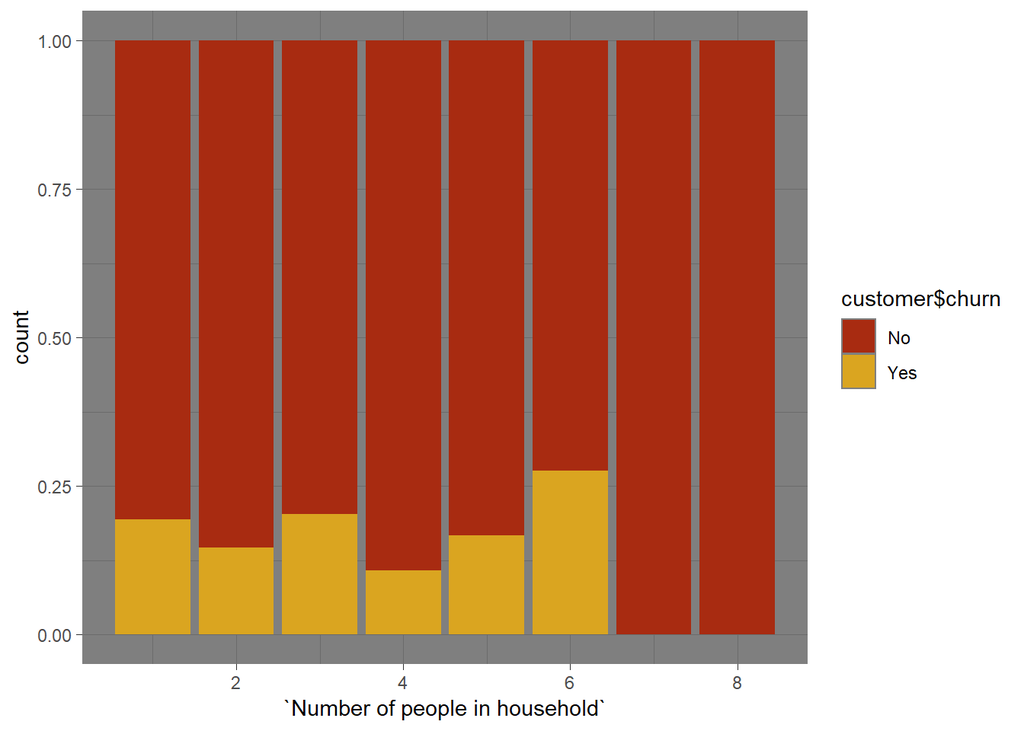

```r
# Best to use for loop in order to reduce amount of code (but here for better clarity I code all)
ggplot(cat4) +
  geom_bar(aes(x = `Number of people in household`, fill = customer$churn ), position = "fill", stat = "count",
           show.legend = T) + scale_fill_manual(values=gucci.colours) + theme_dark()
```

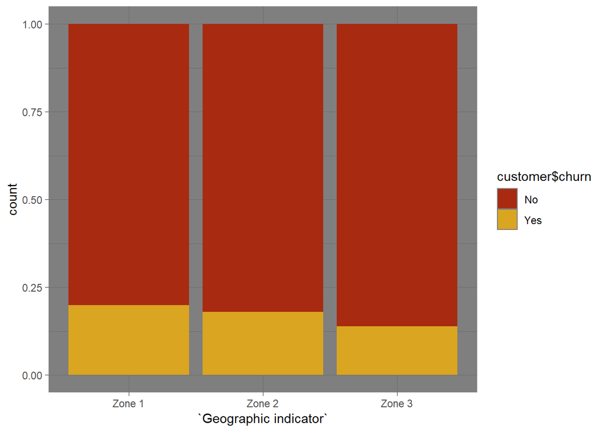

```r
ggplot(cat4) +
  geom_bar(aes(x = `Geographic indicator`, fill = customer$churn ), position = "fill", stat = "count",
           show.legend = T) +   scale_fill_manual(values=gucci.colours) + theme_dark()
```

Customers tend to churn more in zone 1 compared to zone 3. However the difference from zone 2 compared with zone 1 and zone 3 does not seem to be very significant.

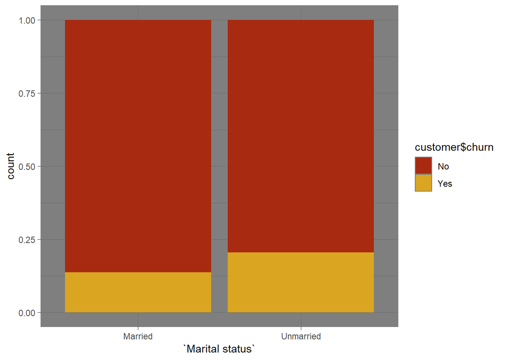

```r
ggplot(cat4) +
  geom_bar(aes(x = `Marital status`, fill = customer$churn), position = "fill", stat = "count",
           show.legend = T) +   scale_fill_manual(values=gucci.colours) + theme_dark()
```

Unmarried customers seem to be having a slightly higher churn rate, but not drastically of course!

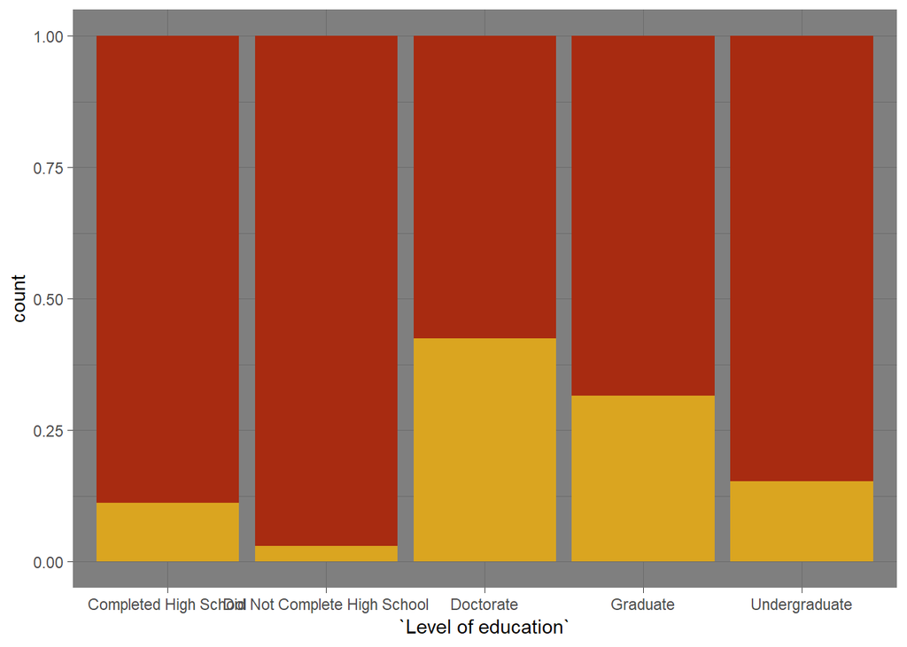

```r
ggplot(cat4) +
  geom_bar(aes(x = `Level of education`, fill = customer$churn), position = "fill", stat = "count",
           show.legend = F) + scale_x_discrete(labels = c("Completed High School", "Did Not Complete High School",
                              "Doctorate", "Graduate", "Undergraduate")) +  scale_fill_manual(values=gucci.colours) +           theme_dark()
```

There seems to be high variability in the distribution based on levels of educations. There is a very concerning amount of churn among those with Doctorate level of education and graduates while it is very low among those who did not complete high school.

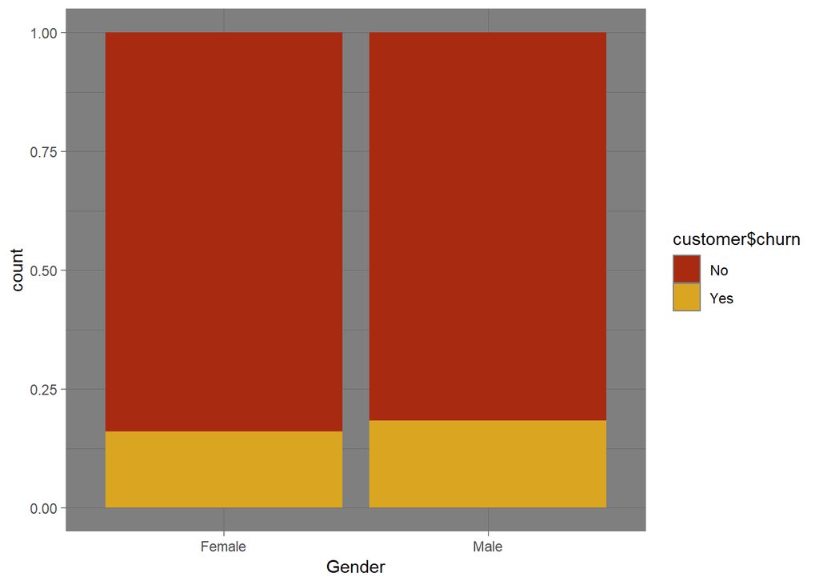

```r
ggplot(cat4) + geom_bar(aes(x = Gender , fill = customer$churn), position = "fill", stat = "count",
           show.legend = T) + scale_fill_manual(values=gucci.colours) + theme_dark()
```

The churn rate is the same between males and females, so we can’t rely on this variable as a good predictor in the future.

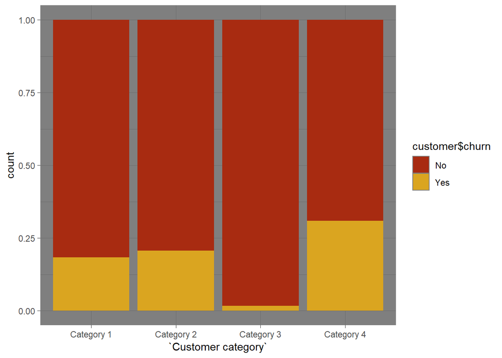

```r
ggplot(cat4) +
  geom_bar(aes(x = `Customer category`, fill = customer$churn), position = "fill", stat = "count",
           show.legend = T) + scale_fill_manual(values=gucci.colours) + theme_dark()
```

Customers in category 4 has a very high churn rate and they are much closer to half of the counts compared to the other categories. This is while, in category 3 the rate is very low.

# Model Fitting

## Logistic Regression

Setting up parralellisation

```r
cores <- makeCluster(detectCores()-2)
registerDoParallel(cores = cores)
```

creating new data frame without customer ID

```r
cus <- subset(customer, select = -c(Customer))
```

Creating Dummy variables for (yes/no) binomial variables

```r
cus %>% mutate(Churn = ifelse(cus$churn == "Yes", 1, 0)) -> cus
cus %>% mutate(marital_status = ifelse(cus$`Marital status` == "Married", 1, 0)) -> cus
cus %>% mutate(retired = ifelse(cus$Retired == "Yes", 1, 0)) -> cus
cus %>% mutate(gender = ifelse(cus$Gender== "Female", 1, 0)) -> cus
cus %>% mutate(toll_free_service = ifelse(cus$`Toll free service`== "Yes", 1, 0)) -> cus
cus %>% mutate(equipment_rental = ifelse(cus$`Equipment rental`== "Yes", 1, 0)) -> cus
cus %>% mutate(calling_card_service = ifelse(cus$`Calling card service`== "Yes", 1, 0)) -> cus
cus %>% mutate(wireless_service = ifelse(cus$`Wireless service`== "Yes", 1, 0)) -> cus
cus %>% mutate(multiple_lines = ifelse(cus$`Multiple lines`== "Yes", 1, 0)) -> cus
cus %>% mutate(voice_mail = ifelse(cus$`Voice mail`== "Yes", 1, 0)) -> cus
cus %>% mutate(paging_service = ifelse(cus$`Paging service`== "Yes", 1, 0)) -> cus
cus %>% mutate(internet = ifelse(cus$Internet== "Yes", 1, 0)) -> cus
cus %>% mutate(caller_ID = ifelse(cus$`Caller ID`== "Yes", 1, 0)) -> cus
cus %>% mutate(call_waiting = ifelse(cus$`Call waiting`== "Yes", 1, 0)) -> cus
cus %>% mutate(call_forwarding = ifelse(cus$`Call forwarding`== "Yes", 1, 0)) -> cus
cus %>% mutate(three_way_calling = ifelse(cus$`Three way calling`== "Yes", 1, 0)) -> cus
cus %>% mutate(electronic_billing = ifelse(cus$`Electronic billing`== "Yes", 1, 0)) -> cus
```

Removing redundant variables that we do not need anymore:

```r
cus <- dplyr::select(cus, - c(churn, `Marital status`, Retired, Gender, `Toll free service`,`Equipment rental`,
                      `Calling card service`,`Wireless service`,`Multiple lines`,`Voice mail`,
                      `Paging service`,Internet,`Caller ID`,`Call waiting`,`Call waiting`,
                      `Call forwarding`,`Three way calling`,`Electronic billing`))
```

At this stage we split data in train and test sets, since the data set is imbalanced we get help from createpartition function to pick up churn rates in an equal proportion for train and test sets.

```r
set.seed(1234)
train.indices <- createDataPartition(cus$Churn, p=0.7, list = FALSE)
train <- cus[train.indices,]
holdout <- cus[-train.indices,]
```

Verifying if the train and holdout data has a close proportion of churn rate

```r
train %>%
  summarise(Total_Obs = n(), Churn_num = sum(Churn == 1), Churn_prop = Churn_num/Total_Obs)
```

```
##   Total_Obs Churn_num Churn_prop
## 1       700       127  0.1814286
```

```r
# Total_Obs Churn_num Churn_prop
# 1       700       123  0.1757143
holdout %>%
  summarise(Total_Obs = n(), Churn_num = sum(Churn == 1), Churn_prop = Churn_num/Total_Obs)
```

```
##   Total_Obs Churn_num Churn_prop
## 1       300        45       0.15
```

```r
# Total_Obs Churn_num Churn_prop
# 1       300        49  0.1633333
```

```r
gmlfull <- glm(train$Churn ~ `Household income in thousands` +  `Number of people in household`+ `Long distance last month` +
               `Toll free last month` + `Equipment last month` + `Calling card last month` +
                 `Geographic indicator` + `Level of education` + `Customer category` + marital_status + retired +
                 gender + multiple_lines + voice_mail + paging_service + internet + caller_ID + call_waiting +
                 call_forwarding + three_way_calling + electronic_billing
                 , family = "binomial", data = train)
summary(gmlfull)
```

```
##
## Call:
## glm(formula = train$Churn ~ `Household income in thousands` +
##     `Number of people in household` + `Long distance last month` +
##     `Toll free last month` + `Equipment last month` + `Calling card last month` +
##     `Geographic indicator` + `Level of education` + `Customer category` +
##     marital_status + retired + gender + multiple_lines + voice_mail +
##     paging_service + internet + caller_ID + call_waiting + call_forwarding +
##     three_way_calling + electronic_billing, family = "binomial",
##     data = train)
##
## Deviance Residuals:
##     Min       1Q   Median       3Q      Max
## -2.4183  -0.1823  -0.0335  -0.0005   3.7098
##
## Coefficients:
##                                                   Estimate Std. Error
## (Intercept)                                       0.956827   0.729813
## `Household income in thousands`                  -0.006255   0.003875
## `Number of people in household`                  -0.325091   0.158714
## `Long distance last month`                       -0.543107   0.076547
## `Toll free last month`                            0.007822   0.020727
## `Equipment last month`                            0.093060   0.015351
## `Calling card last month`                        -0.064259   0.021505
## `Geographic indicator`Zone 2                     -0.448753   0.431172
## `Geographic indicator`Zone 3                     -1.492307   0.447087
## `Level of education`Did Not Complete High School -0.753572   0.755885
## `Level of education`Doctorate                     0.462869   0.651656
## `Level of education`Graduate                      0.697435   0.471452
## `Level of education`Undergraduate                -0.796707   0.518830
## `Customer category`Category 2                     1.350650   0.733137
## `Customer category`Category 3                    -0.500092   1.044077
## `Customer category`Category 4                     0.422430   1.028496
## marital_status                                    0.318520   0.470814
## retired                                          -1.895866   1.366582
## gender                                           -0.255016   0.338455
## multiple_lines                                   -0.347798   0.590998
## voice_mail                                       -0.134887   0.480978
## paging_service                                    0.018182   0.542918
## internet                                          0.648943   0.408151
```

[output cut: 29 more lines]

```
## caller_ID                                         -0.465 0.641957
## call_waiting                                      -0.203 0.839088
## call_forwarding                                    1.074 0.282998
## three_way_calling                                 -1.189 0.234491
## electronic_billing                                 3.275 0.001058 **
## ---
## Signif. codes:  0 '***' 0.001 '**' 0.01 '*' 0.05 '.' 0.1 ' ' 1
##
## (Dispersion parameter for binomial family taken to be 1)
##
##     Null deviance: 662.97  on 699  degrees of freedom
## Residual deviance: 244.00  on 672  degrees of freedom
## AIC: 300
##
## Number of Fisher Scoring iterations: 8
```

Checking collinearity in the model

```r
vif(stepGLM)
```

[output not shown]

```
##                                     GVIF Df GVIF^(1/(2*Df))
## `Household income in thousands` 1.105848  1        1.051593
## `Number of people in household` 1.122092  1        1.059289
## `Long distance last month`      1.459141  1        1.207949
## `Equipment last month`          2.052063  1        1.432502
## `Calling card last month`       1.559540  1        1.248816
## `Geographic indicator`          1.337801  2        1.075469
## `Level of education`            1.621225  4        1.062259
## retired                         1.093595  1        1.045751
## internet                        1.320059  1        1.148938
## three_way_calling               1.576809  1        1.255710
## electronic_billing              1.284368  1        1.133300
```

When I reached this stage, I used the correlation plot from the exploratory analysis part back and fourth to find relationships between the variables and tried to make more sense out of them. It took about 3 or 4 times running VIF and cross checking correlations as well as analyzing them to be able to have a sensible choice of predictors. Another future work that I would consider is to scale variables to check if there is any improvement in correlation among them before removing them when including them in the model.

I have attached the code for dummy variables in case it is needed for future usage: # Generate dummy data

```r
# dummyData <- dummyVars("~ .", data = cus)
# dummyData <- data.frame(predict(dummyData,newdata=cus))
```

Running GLM with dummy shows, since I have used dummy variables, there is singularity among dummy variables as the first category will not be absorbed by the intercept. Therefore, I need to remove the last level of the categorical variables to avoid singularity. I can spot those easily by looking at the coefficient of the glm model which are equal to NA.

Removing last level of the categories to avoid singularities:

```r
# dummyData$X.Geographic.indicator.Zone.3 <- NULL
# dummyData$X.Level.of.education.Undergraduate <- NULL
# dummyData$X.Customer.category.Category.4 <- NULL
```

(Commented the above code as we don’t need it at this stage)

Continuing with our model selection. I ran the step function after removing the variables with large p-values:

```r
stepGLM1 <- glm(formula = train$Churn ~ `Long distance last month` + `Toll free last month` + `Equipment last month` +
                  `Calling card last month` + `Geographic indicator` + `Level of education` +
                  retired + call_forwarding + electronic_billing,
                family = "binomial", data = train)
summary(stepGLM1)
```

```
##
## Call:
## glm(formula = train$Churn ~ `Long distance last month` + `Toll free last month` +
##     `Equipment last month` + `Calling card last month` + `Geographic indicator` +
##     `Level of education` + retired + call_forwarding + electronic_billing,
##     family = "binomial", data = train)
##
## Deviance Residuals:
##     Min       1Q   Median       3Q      Max
## -2.6288  -0.2368  -0.0493  -0.0012   3.4790
##
## Coefficients:
##                                                  Estimate Std. Error
## (Intercept)                                       0.20078    0.54381
## `Long distance last month`                       -0.50057    0.06567
## `Toll free last month`                           -0.01453    0.01962
## `Equipment last month`                            0.09548    0.01311
## `Calling card last month`                        -0.06793    0.01959
## `Geographic indicator`Zone 2                     -0.49239    0.38845
## `Geographic indicator`Zone 3                     -1.34606    0.40503
## `Level of education`Did Not Complete High School -0.75003    0.72210
## `Level of education`Doctorate                     0.60832    0.58500
## `Level of education`Graduate                      0.84955    0.43129
## `Level of education`Undergraduate                -0.68154    0.46665
## retired                                          -2.01688    1.24205
## call_forwarding                                  -0.04063    0.47772
## electronic_billing                                1.38665    0.37801
##                                                  z value Pr(>|z|)
## (Intercept)                                        0.369 0.711967
## `Long distance last month`                        -7.623 2.48e-14 ***
## `Toll free last month`                            -0.741 0.458990
## `Equipment last month`                             7.285 3.21e-13 ***
## `Calling card last month`                         -3.467 0.000526 ***
## `Geographic indicator`Zone 2                      -1.268 0.204952
## `Geographic indicator`Zone 3                      -3.323 0.000889 ***
## `Level of education`Did Not Complete High School  -1.039 0.298955
## `Level of education`Doctorate                      1.040 0.298406
## `Level of education`Graduate                       1.970 0.048863 *
## `Level of education`Undergraduate                 -1.460 0.144154
## retired                                           -1.624 0.104413
## call_forwarding                                   -0.085 0.932223
## electronic_billing                                 3.668 0.000244 ***
## ---
## Signif. codes:  0 '***' 0.001 '**' 0.01 '*' 0.05 '.' 0.1 ' ' 1
##
## (Dispersion parameter for binomial family taken to be 1)
##
##     Null deviance: 662.97  on 699  degrees of freedom
## Residual deviance: 268.06  on 686  degrees of freedom
## AIC: 296.06
##
## Number of Fisher Scoring iterations: 8
```

Running step() again to check if there is any improvement in AIC:

```r
summary(stepGLM2)
```

```
##
## Call:
## glm(formula = train$Churn ~ `Long distance last month` + `Equipment last month` +
##     `Calling card last month` + `Geographic indicator` + `Level of education` +
##     retired + electronic_billing, family = "binomial", data = train)
##
## Deviance Residuals:
##     Min       1Q   Median       3Q      Max
## -2.6527  -0.2372  -0.0498  -0.0011   3.5160
##
## Coefficients:
##                                                  Estimate Std. Error
## (Intercept)                                       0.16960    0.53866
## `Long distance last month`                       -0.50363    0.06481
## `Equipment last month`                            0.09141    0.01213
## `Calling card last month`                        -0.07459    0.01782
## `Geographic indicator`Zone 2                     -0.51671    0.38633
## `Geographic indicator`Zone 3                     -1.37481    0.40430
## `Level of education`Did Not Complete High School -0.70953    0.71954
## `Level of education`Doctorate                     0.64477    0.58064
## `Level of education`Graduate                      0.86432    0.43067
## `Level of education`Undergraduate                -0.65217    0.46488
## retired                                          -2.10990    1.24236
## electronic_billing                                1.46275    0.36955
##                                                  z value Pr(>|z|)
## (Intercept)                                        0.315 0.752875
## `Long distance last month`                        -7.771 7.81e-15 ***
## `Equipment last month`                             7.533 4.95e-14 ***
## `Calling card last month`                         -4.185 2.85e-05 ***
## `Geographic indicator`Zone 2                      -1.337 0.181073
## `Geographic indicator`Zone 3                      -3.400 0.000673 ***
## `Level of education`Did Not Complete High School  -0.986 0.324093
## `Level of education`Doctorate                      1.110 0.266806
## `Level of education`Graduate                       2.007 0.044756 *
## `Level of education`Undergraduate                 -1.403 0.160656
## retired                                           -1.698 0.089452 .
## electronic_billing                                 3.958 7.55e-05 ***
## ---
## Signif. codes:  0 '***' 0.001 '**' 0.01 '*' 0.05 '.' 0.1 ' ' 1
##
## (Dispersion parameter for binomial family taken to be 1)
##
##     Null deviance: 662.97  on 699  degrees of freedom
## Residual deviance: 269.05  on 688  degrees of freedom
## AIC: 293.05
##
## Number of Fisher Scoring iterations: 8
```

Step function does not improve the AIC at this stage anymore. However, there are still large p-values. Therefore, I’ll remove `retired` variable and `levels of education`.

```r
stepGLM3 <- glm(formula = train$Churn ~ `Long distance last month` + `Equipment last month` +
    `Calling card last month` + `Geographic indicator` +
     electronic_billing, family = "binomial", data = train)
summary(stepGLM3)
```

```
##
## Call:
## glm(formula = train$Churn ~ `Long distance last month` + `Equipment last month` +
##     `Calling card last month` + `Geographic indicator` + electronic_billing,
##     family = "binomial", data = train)
##
## Deviance Residuals:
##     Min       1Q   Median       3Q      Max
## -2.3996  -0.2707  -0.0680  -0.0022   3.5229
##
## Coefficients:
##                              Estimate Std. Error z value Pr(>|z|)
## (Intercept)                  -0.10197    0.43858  -0.233 0.816149
## `Long distance last month`   -0.46793    0.06035  -7.753 8.97e-15 ***
## `Equipment last month`        0.09089    0.01118   8.128 4.38e-16 ***
## `Calling card last month`    -0.06604    0.01618  -4.082 4.46e-05 ***
## `Geographic indicator`Zone 2 -0.50566    0.36885  -1.371 0.170402
## `Geographic indicator`Zone 3 -1.26190    0.38296  -3.295 0.000984 ***
## electronic_billing            1.57503    0.35036   4.495 6.94e-06 ***
## ---
## Signif. codes:  0 '***' 0.001 '**' 0.01 '*' 0.05 '.' 0.1 ' ' 1
##
## (Dispersion parameter for binomial family taken to be 1)
##
##     Null deviance: 662.97  on 699  degrees of freedom
## Residual deviance: 287.85  on 693  degrees of freedom
## AIC: 301.85
##
## Number of Fisher Scoring iterations: 8
```

```r
vif(stepGLM3)
```

```
##                                GVIF Df GVIF^(1/(2*Df))
## `Long distance last month` 1.329356  1        1.152977
## `Equipment last month`     1.627002  1        1.275540
## `Calling card last month`  1.246224  1        1.116344
## `Geographic indicator`     1.114854  2        1.027554
## electronic_billing         1.201410  1        1.096088
```

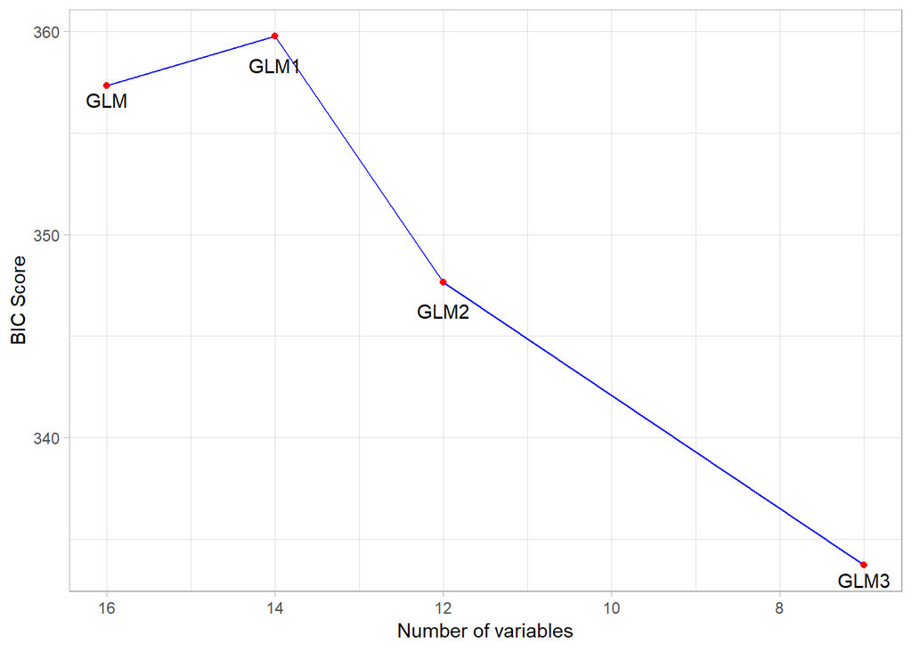

```r
MyBIC <- BIC(stepGLM3,stepGLM2,stepGLM1,stepGLM)

ggplot(MyBIC, aes(x= df, y= BIC, label=c("\nGLM3","\n\nGLM2","\n\nGLM1","\nGLM"))) +
                  geom_line(col ="blue") +
                  geom_point(col="red") +
                  geom_text() +
                  scale_x_reverse() +
                  xlab("Number of variables") + ylab("BIC Score") +
                  theme_light()
```

Before, ending this section, I am curious to check the improvement of my models as we removed covariates. Therefore, I used BIC as a gauge to check that since the penalty term is larger in BIC than in AIC for any additional parameters (variables) using Log(N) * p. Per above plot, it can be seen that from full model (16 variables) to GLM1 model (14 variables) the score has not been improved even with the lower number of variables. However, after that there is a downward trend which is satisfying for this case.

# Prediction, Confusion Matrix and Receiver Operating Characteristics Curve (ROC)

I will obtain probabilities of the prediction and set the threshold to 50% temporarily so I can have it as a baseline later on for comparison purposes.

```r
train_prob <- predict(stepGLM3, data = train, type = "response")
train_pred   <- factor(ifelse(train_prob >= 0.5, "Yes", "No"))
train_actual <- factor(ifelse(train$Churn == 1, "Yes", "No"))
holdout_prob  <- predict(stepGLM3, newdata = holdout, type = "response")
holdout_pred    <- factor(ifelse(holdout_prob >= 0.5, "Yes", "No"))
holdout_actual  <- factor(ifelse(holdout$Churn == 1, "Yes", "No"))
```

## Confusion Matrix

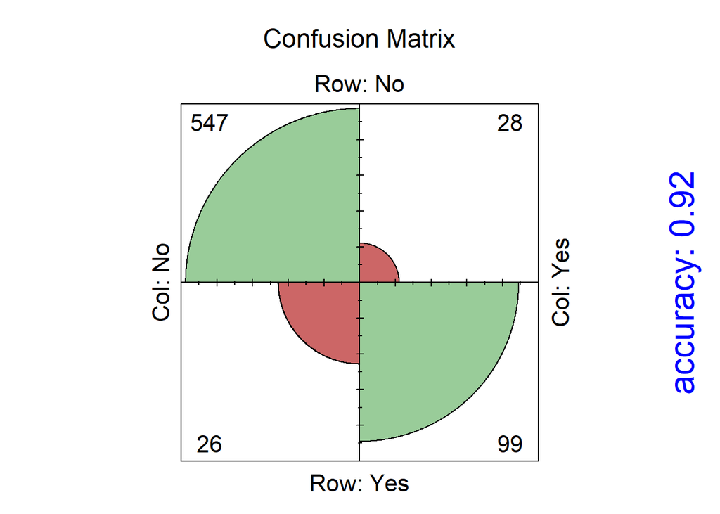

```r
cm <- confusionMatrix(data = train_pred, reference = train_actual)
mtable <- as.table(as.matrix(cm))
fourfoldplot(mtable, color = c("#CC6666", "#99CC99"),
             conf.level = 0, margin = 1, main = "Confusion Matrix")
mtext(paste("accuracy:", format(round(cm$overall["Accuracy"], 2), nsmall = 2)), col = "blue", cex = 2, side = 4)
```

Confusion matrix shows 0.92 (rounded) accuracy.

## ROC curve with AUC and Confidence Interval

I’ll proceed and produce Confusion matrix and ROC curve for the training set first:

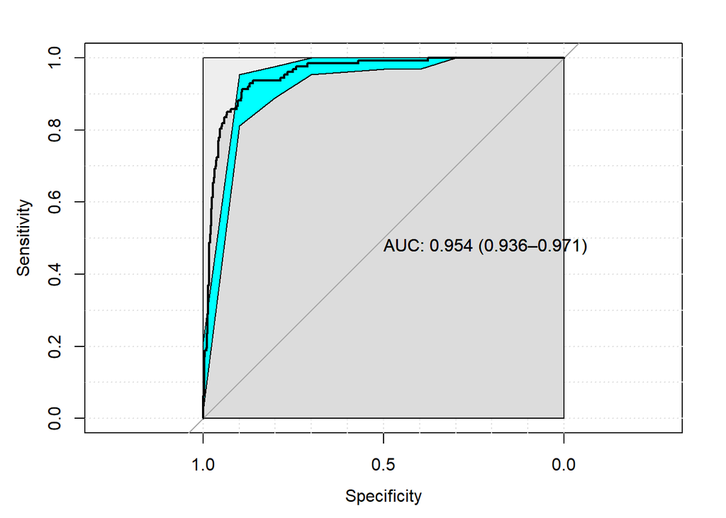

```r
pROC_obj <- roc(train$Churn,train_prob,
                smoothed = TRUE,
                ci=TRUE, ci.alpha=0.9, stratified=FALSE,
                plot=TRUE, auc.polygon=TRUE, max.auc.polygon=TRUE, grid=TRUE,
                print.auc=TRUE, show.thres=TRUE)
# calculating confidence interval using 2000 bootstraps
sens.ci <- ci.se(pROC_obj)
plot(sens.ci, type="shape", col="cyan")
```

In this ROC Curve, I decided to compute the confidence interval (CI) of the sensitivity at the given specificity points. By default, the 95% CI are computed with 2000 stratified bootstrap replicates. The AUC is 0.954 with (0.936-0.971) 95% confidence interval.

And now for the holdout (test) set:

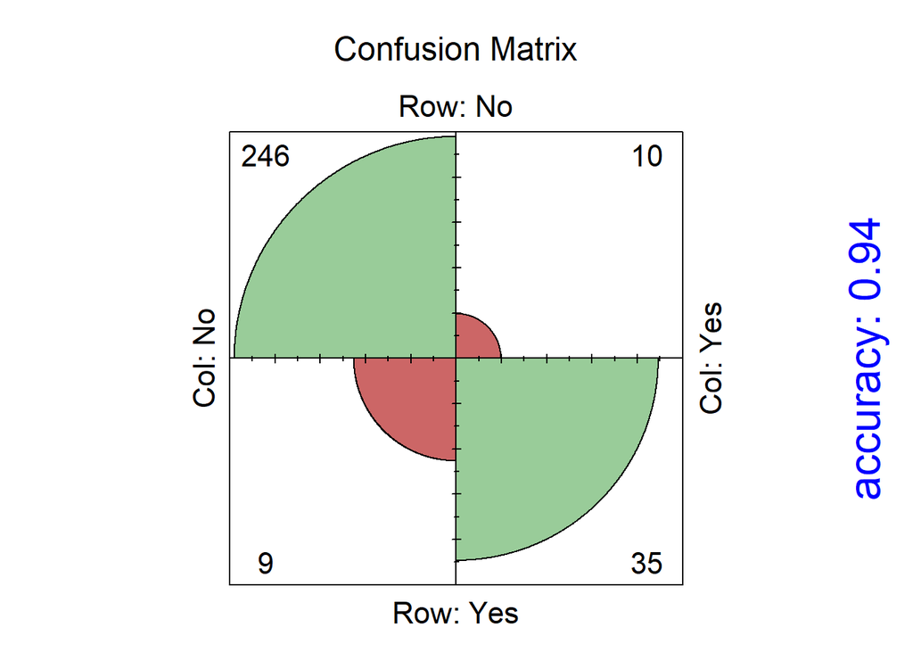

```r
cm <- confusionMatrix(data = holdout_pred, reference = holdout_actual)
mtable <- as.table(as.matrix(cm))
fourfoldplot(mtable, color = c("#CC6666", "#99CC99"),
             conf.level = 0, margin = 1, main = "Confusion Matrix")
mtext(paste("accuracy:", format(round(cm$overall["Accuracy"], 2), nsmall = 2)), col = "blue", cex = 2, side = 4)
```

For the holdout set it gets 94% (rounded) accuracy.

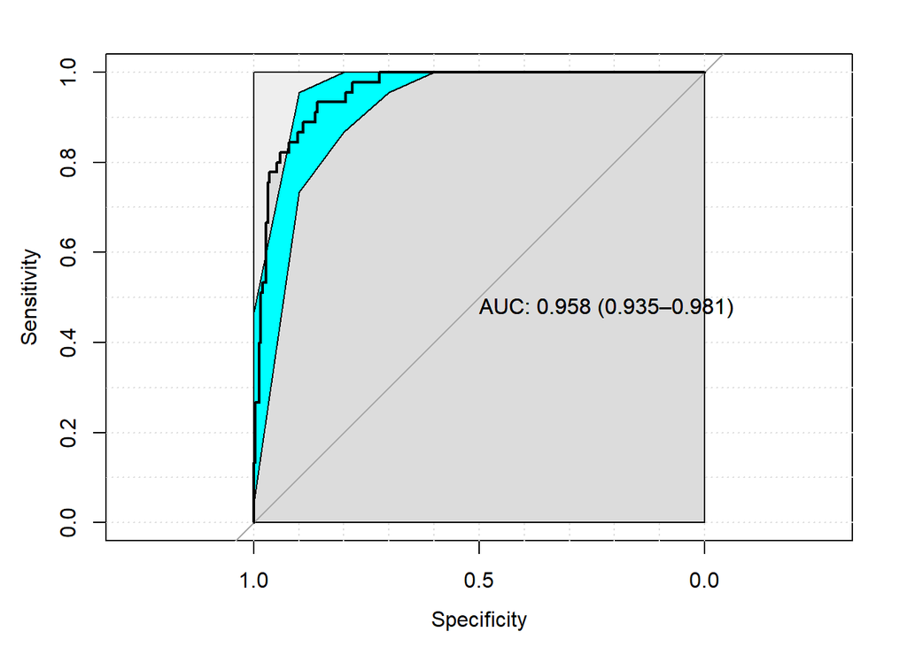

```r
pROC_obj <- roc(holdout$Churn,holdout_prob,
                smoothed = TRUE,
                ci=TRUE, ci.alpha=0.9, stratified=FALSE,
                plot=TRUE, auc.polygon=TRUE, max.auc.polygon=TRUE, grid=TRUE,
                print.auc=TRUE, show.thres=TRUE)
sens.ci <- ci.se(pROC_obj)
plot(sens.ci, type="shape", col="cyan")
```

The AUC is 0.958 with (0.935-0.981) confidence interval. After assessing the model with 0.5 threshold. I proceed to find the optimal threshold for the model. So, then I can improve the performance.

I create a prediction object using prediction and true class label and evaluate the predictors using performance function over prediction object, created already.

```r
GLMprediction <- prediction(train_prob, train_actual)
GLMperformance <- performance(GLMprediction, "spec", "sens")
```

Then I extract the cutoffs and determine where the alpha is minimum when checking the difference of specificity and sensitivity which is our optimal cutoff:

```r
ALLcutoffs <- data.frame(alpha_value=GLMperformance@alpha.values[[1]],
                         specificity=GLMperformance@x.values[[1]],
                         sensitivity= GLMperformance@y.values[[1]])
opt_cutoff <- ALLcutoffs[which.min(abs(ALLcutoffs$specificity-ALLcutoffs$sensitivity)),]
```

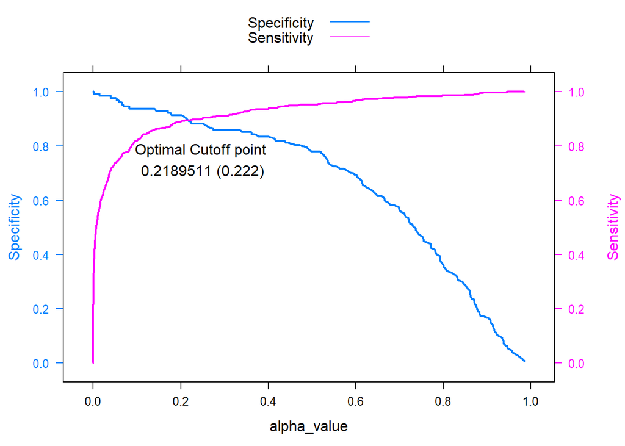

```r
obj1 <- xyplot(ALLcutoffs$specificity ~ alpha_value, ALLcutoffs, type = "l" , lwd=2, ylab = "Specificity")
obj2 <- xyplot(ALLcutoffs$sensitivity ~ alpha_value, ALLcutoffs, type = "l", lwd=2, ylab = "Sensitivity")
doubleYScale(obj1, obj2, text = c("Specificity", "Sensitivity") , add.ylab2 = TRUE) +
  latticeExtra::layer(panel.text(x=0.25, y=0.75, label="Optimal Cutoff point \n0.2189511 (0.222)"))
```

Now, I set the predictions according to the obtained cutoff point (0.222):

```r
optcut_train_prob <- predict(stepGLM3, data = train, type = "response")
optcut_train_pred   <- factor(ifelse(train_prob >= 0.222, "Yes", "No"))
optcut_train_actual <- factor(ifelse(train$Churn == 1, "Yes", "No"))

optcut_holdout_prob  <- predict(stepGLM3, newdata = holdout, type = "response")
optcut_holdout_pred    <- factor(ifelse(holdout_prob >= 0.222, "Yes", "No"))
optcut_holdout_actual  <- factor(ifelse(holdout$Churn == 1, "Yes", "No"))
```

Producing confusion matrix to check the differences after the optimal cutoff point first got the training set and then for the holdout set. Training set:

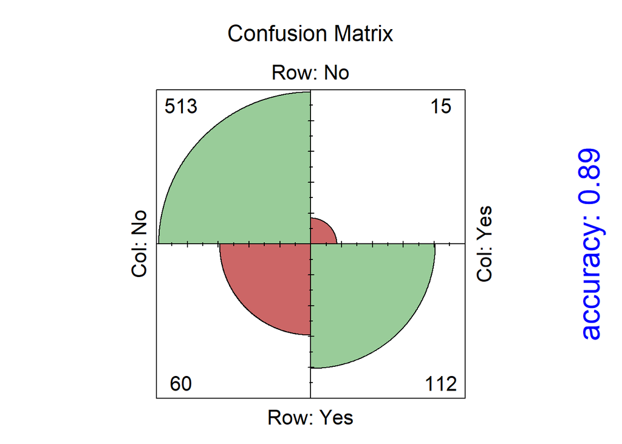

```r
cm <- confusionMatrix(data = optcut_train_pred, reference = train_actual)
mtable <- as.table(as.matrix(cm))
fourfoldplot(mtable, color = c("#CC6666", "#99CC99"),
             conf.level = 0, margin = 1, main = "Confusion Matrix")
mtext(paste("accuracy:", format(round(cm$overall["Accuracy"], 2), nsmall = 2)), col = "blue", cex = 2, side = 4)
```

ROC for the training set with optimal cut off point 0.222:

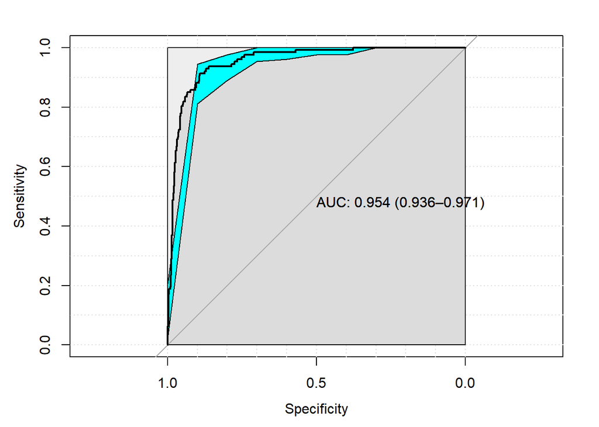

```r
pROC_obj <- roc(train$Churn,optcut_train_prob,
                smoothed = TRUE,
                ci=TRUE, ci.alpha=0.9, stratified=FALSE,
                plot=TRUE, auc.polygon=TRUE, max.auc.polygon=TRUE, grid=TRUE,
                print.auc=TRUE, show.thres=TRUE)
sens.ci <- ci.se(pROC_obj)
plot(sens.ci, type="shape", col="cyan")
```

Holdout set:

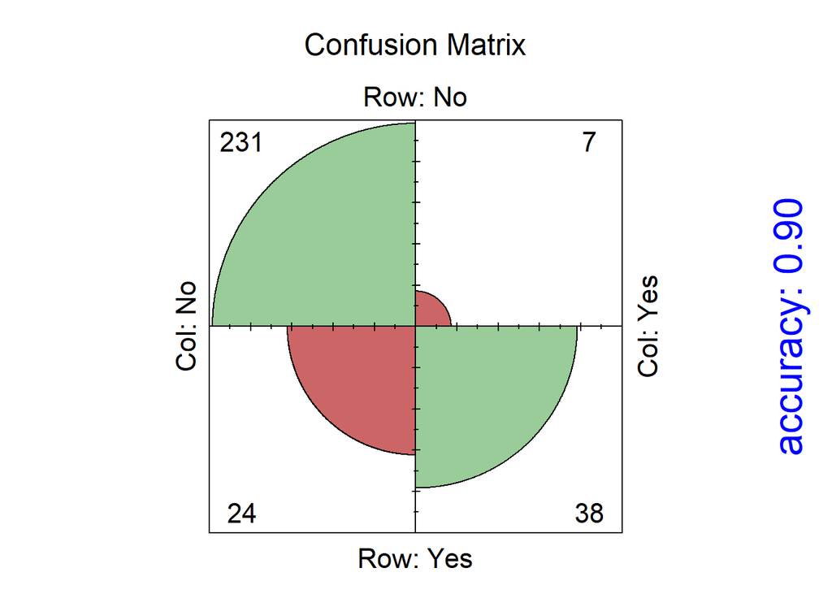

```r
optcut_holdout_pred <- factor(ifelse(holdout_prob >= 0.222, "Yes", "No"))

cm <- confusionMatrix(data = optcut_holdout_pred, reference = holdout_actual)
mtable <- as.table(as.matrix(cm))
fourfoldplot(mtable, color = c("#CC6666", "#99CC99"),
             conf.level = 0, margin = 1, main = "Confusion Matrix")
mtext(paste("accuracy:", format(round(cm$overall["Accuracy"], 2), nsmall = 2)), col = "blue", cex = 2, side = 4)
```

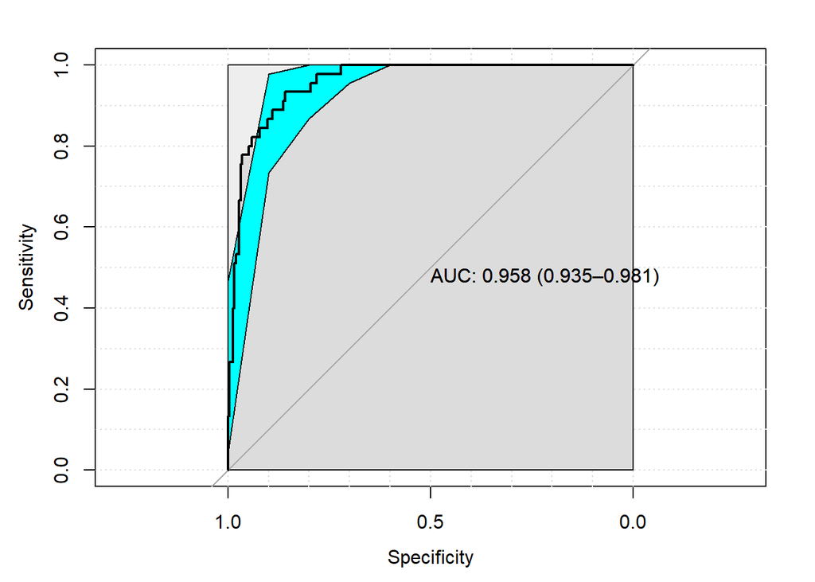

```r
pROC_obj <- roc(holdout$Churn,optcut_holdout_prob,
                smoothed = TRUE,
                ci=TRUE, ci.alpha=0.9, stratified=FALSE,
                plot=TRUE, auc.polygon=TRUE, max.auc.polygon=TRUE, grid=TRUE,
                print.auc=TRUE, show.thres=TRUE)
sens.ci <- ci.se(pROC_obj)
plot(sens.ci, type="shape", col="cyan")
```

# Model Assessment

Running Anova, marginal (Type II) test for further checking of the model. Anova can be used with F-test and to check the covariates accordingly as more variability can be accounted for by using F-test

```r
Anova(stepGLM3)
```

```
## Analysis of Deviance Table (Type II tests)
##
## Response: train$Churn
##                            LR Chisq Df Pr(>Chisq)
## `Long distance last month`  122.618  1  < 2.2e-16 ***
## `Equipment last month`       95.631  1  < 2.2e-16 ***
## `Calling card last month`    19.012  1  1.299e-05 ***
## `Geographic indicator`       11.663  2   0.002934 **
## electronic_billing           21.297  1  3.933e-06 ***
## ---
## Signif. codes:  0 '***' 0.001 '**' 0.01 '*' 0.05 '.' 0.1 ' ' 1
```

The Anova test verifies significance of the variables, so there are not concerns at this stage.

## Assessing influential points

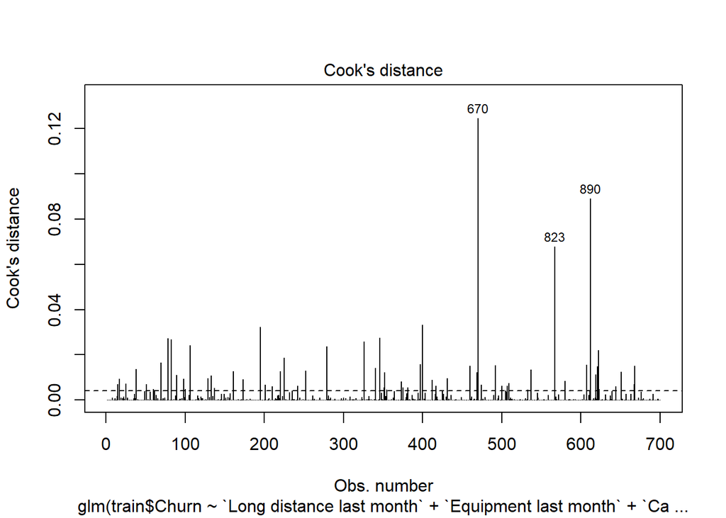

```r
plot(stepGLM3, which =4)
abline(h=4/nrow(customer),lty=2)
```

Assessing the Cook’s distance and using the rule of thumb of 4 divided by the number of data points (the dotted horizontal line). There are few influential points. This can be addressed by adding more predictors to the model or checking the data collection.

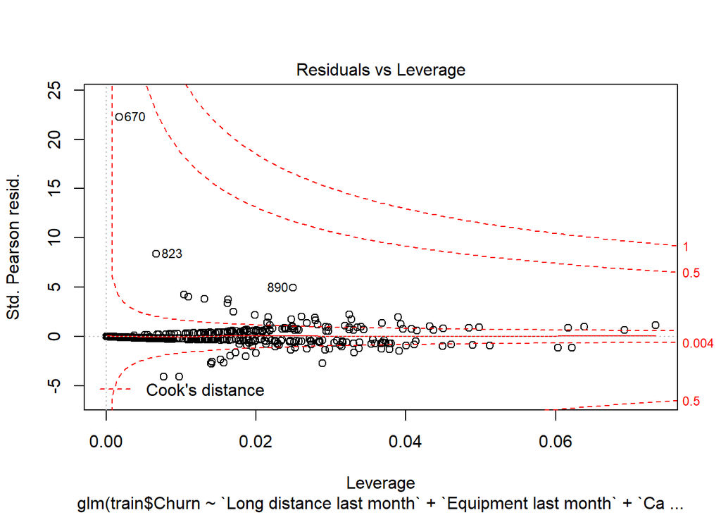

```r
plot(stepGLM3, which = 5, add.smooth = TRUE, cook.levels = c(4/1000, 0.5, 1))
```

To further investigate any influential residuals (above), I decided to plot them against leverage and 3 criteria: first, 4 over number of rows; second, 0.5 and finally, 1. There are few points that exceeded the first rule, however, there are no other points beyond the second and third limit.

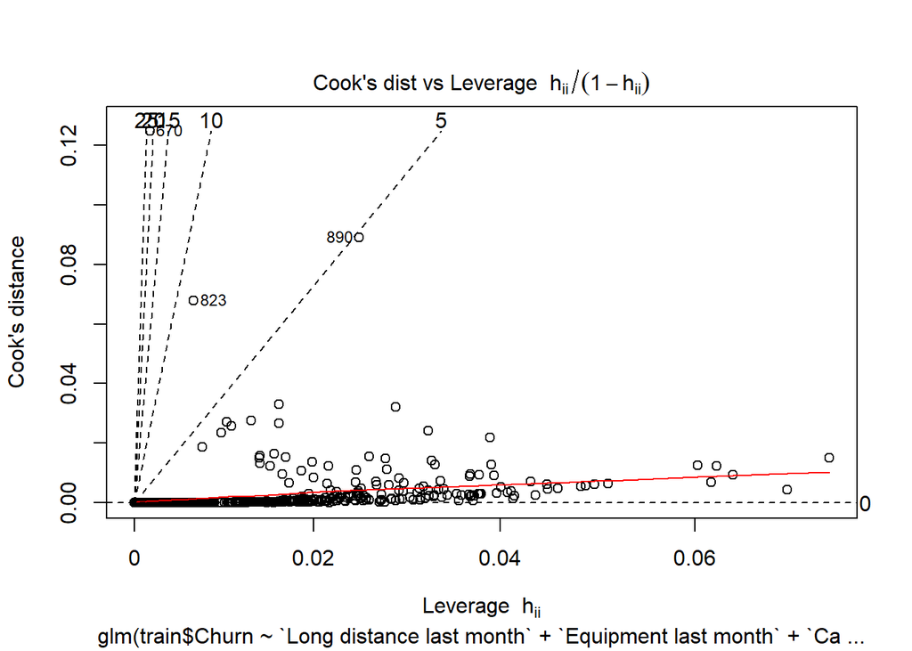

```r
plot(stepGLM3, which = 6, add.smooth = TRUE, cook.levels = c(4/1000, 0.5, 1))
```